# Exponential Distribution and Compairing with CLT

Vasudha Singh

December 6, 2018

install.packages(“knitr”)  
install.packages(“markdown”)  
install.packages(“rmarkdown”)

## Overview

In this project we will investigate the exponential distribution in R and compare it with the Central Limit Theorem. The mean of exponential distribution is 1/lambda and the standard deviation is also 1/lambda. For analysis purpose, we will set lambda = 0.2 for all of the simulations and this investigation will compare with the distribution of averages of 40 exponentials over 1000 Simulations.

## Simulations

Set the simulation variables and Run Simulation

```r
set.seed(6817)
n<-40
lambda<-0.2
nosim<-1000
simMeans <- NULL
for(i in 1:1000) simMeans= c(simMeans, mean(rexp(n, lambda)))
```

## Sample mean Versus Theoretical mean

### Sample Mean

Calculating mean from Simulations

```r
 mean(simMeans)
```

```
## [1] 5.017058
```

### Theoretical Mean

Calculating mean of Exponential distribution , whose mean is 1/ lambda

```r
 expMeans<-1/lambda
 expMeans
```

```
## [1] 5
```

### Comparison between Sample Mean and Theoretical Mean

```r
 abs(mean(simMeans)-expMeans)
```

```
## [1] 0.01705794
```

This shows that the Center of distribution of Sample Mean 5.0170579 is closely related to Theoretical Mean 5.

## Sample Variance Versus Theoretical Variance

### Sample Variance

Calculating Variance and Standard deviation from Simulations

```r
 var(simMeans)
```

```
## [1] 0.6643289
```

```r
 sd(simMeans)
```

```
## [1] 0.8150637
```

### Theoretical Variance

Calculating Variance of Exponential distribution and standard deviation

```r
 expVariance<-(1/lambda)^2/(n)
 expVariance
```

```
## [1] 0.625
```

```r
 expStdev<- 1/(lambda*sqrt(n))
 expStdev
```

```
## [1] 0.7905694
```

### Comparison between Sample Variance and Theoretical Variance

```r
abs(var(simMeans)-expVariance)
```

```
## [1] 0.03932887
```

This shows that the variability of distribution of Sample Variance 0.6643289 is closely related to Theoretical Variance 0.625.

## Distribution

### Show that distribution is approximately Normal.

The Histogram plot of the means of 1000 simulations is overlaid with the normal distribution with mean 5 and standard deviation 0.7905694.  
This shows the distribution of simulation is normal.

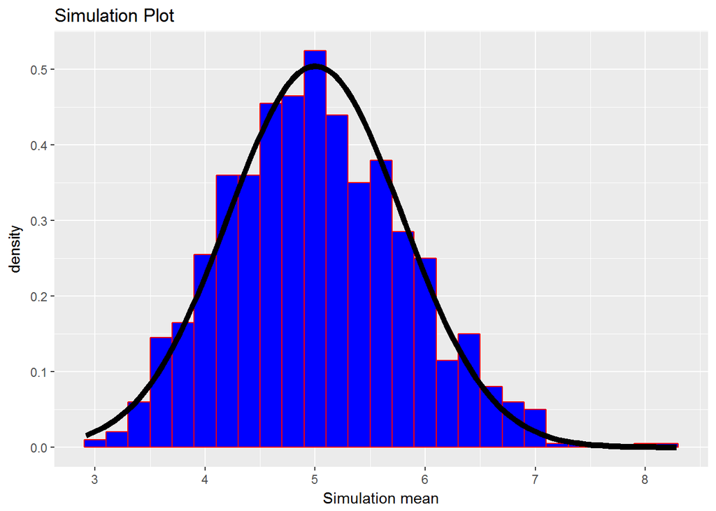

```r
g<-ggplot(data.frame(y=simMeans), aes(x=y))
g<- g+ geom_histogram(aes(y=..density..), binwidth= 0.2, fill="blue", color="red") +
  stat_function(fun=dnorm,args=list(mean=expMeans, sd=expStdev), size=2)+
  ggtitle('Simulation Plot')+ xlab('Simulation mean')+ ylab('density')
g
```